# Анализ рынка видеоигр

В проекте анализируется рынок видеоигр: глобальные продажи различных игр и их продажи в отдельных регионах, в заивисимости от года выхода, платформы, жанра и оценок критиков и пользователей.

Цель проекта: выявить закономерности, позволяющие спрогнозировать успешность игры.

Выборка: более 16.500 игр, выпущенных с 1980 по 2016 год.

### Описание данных

- **name** — название игры
- **platform** — платформа
- **year_of_release** — год выпуска
- **genre** — жанр игры
- **na_sales** — продажи в Северной Америке (миллионы проданных копий)
- **eu_sales** — продажи в Европе (миллионы проданных копий)
- **jp_sales** — продажи в Японии (миллионы проданных копий)
- **other_sales** — продажи в других странах (миллионы проданных копий)
- **critic_score** — оценка критиков (по 100-балльной шкале)
- **user_score** — оценка пользователей (по 10-балльной шкале)
- **rating** — рейтинг от организации ESRB

### Оглавление

Шаг 1. Изучение общей информации.

Шаг 2. Предобработка данных.

Шаг 3. Исследовательский анализ данных.

Шаг 4. Составление портретов пользователей по регионам.

Шаг 5. Статистический анализ данных.

Шаг 6. Общий вывод.

## Шаг 1. Изучение общей информации

```python
import warnings
import pandas as pd
import numpy as np
import matplotlib.pyplot as plt
import seaborn as sns
import scipy.stats as st
```

```python
df = pd.read_csv('')
```

```python
df.info()
```

```
<class 'pandas.core.frame.DataFrame'>
RangeIndex: 16715 entries, 0 to 16714
Data columns (total 11 columns):
Name               16713 non-null object
Platform           16715 non-null object
Year_of_Release    16446 non-null float64
Genre              16713 non-null object
NA_sales           16715 non-null float64
EU_sales           16715 non-null float64
JP_sales           16715 non-null float64
Other_sales        16715 non-null float64
Critic_Score       8137 non-null float64
User_Score         10014 non-null object
Rating             9949 non-null object
dtypes: float64(6), object(5)
memory usage: 1.4+ MB
```

```python
df.head()
```

|  | Name | Platform | Year_of_Release | Genre | NA_sales | EU_sales | JP_sales | Other_sales | Critic_Score | User_Score | Rating |
| --- | --- | --- | --- | --- | --- | --- | --- | --- | --- | --- | --- |
| 0 | Wii Sports | Wii | 2006.0 | Sports | 41.36 | 28.96 | 3.77 | 8.45 | 76.0 | 8 | E |
| 1 | Super Mario Bros. | NES | 1985.0 | Platform | 29.08 | 3.58 | 6.81 | 0.77 | NaN | NaN | NaN |
| 2 | Mario Kart Wii | Wii | 2008.0 | Racing | 15.68 | 12.76 | 3.79 | 3.29 | 82.0 | 8.3 | E |
| 3 | Wii Sports Resort | Wii | 2009.0 | Sports | 15.61 | 10.93 | 3.28 | 2.95 | 80.0 | 8 | E |
| 4 | Pokemon Red/Pokemon Blue | GB | 1996.0 | Role-Playing | 11.27 | 8.89 | 10.22 | 1.00 | NaN | NaN | NaN |

### Вывод

В массиве данных 16715 строк и 11 столбцов.

Каждая строка представляет собой запись об отдельной игре: ее названии, платформе, на которой она вышла, годе выхода, продажах в различных регионах, а также оценке пользователей и критиков. В ячейках с различными оценками пропущены почти половина значений, есть пропущенные значения и в столбце с датой выхода.

## Шаг 2. Предобработка данных

```python
# Приводим названия колонок  к нижнему регистру
warnings.filterwarnings(action='ignore')

column_names_lc = df.columns.get_values().tolist()

for i in range(len(column_names_lc)):
    column_names_lc[i] = column_names_lc[i].lower()

df.columns = column_names_lc
```

```python
# Смотрим, есть ли дублирующиеся строки

df.duplicated().sum()
```

```
0
```

```python
# Заменяем 'tbd' на 'NaN', чтобы затем можно было изменить тип данных на 'float'

df.loc[df['user_score'] == 'tbd', 'user_score'] = np.nan
```

```python
# Удаляем строки с пропущенными значениями года релиза: их меньше трех процентов
# от общего количества строк, поэтому не страшно, зато позволит поменять типа данных для
# столбца. Можно бы было заполнить пропуски, если тайтл выпускался на другой платформе и для
# него есть соответствующая запись с датой выхода, но это не совсем корректно: игры часто
# портируются с значительным временным зазором.

nan_years_ixs = df.loc[df['year_of_release'].isna()].index
df = df.drop(nan_years_ixs).reset_index(drop=True)
```

```python
# Удаляем строки с пропущенными значениями 'name', их всего 2 штуки

nan_name_ixs = df.loc[df['name'].isna()].index
df = df.drop(nan_name_ixs).reset_index(drop=True)
```

```python
# Меняем типы данных. Для стобца 'year_of_release' на 'int', потому что так впоследствии будет
# симпатичнее смотреться на графиках (в данном случае от datetime больше проблем, чем пользы).
# 'user_score', лишенный значений 'tbd', спокойно становится 'float'

df['year_of_release'] = df['year_of_release'].astype('int')
df['user_score'] = df['user_score'].astype('float')
```

```python
# Добавляем столбец с глобальными продажами

df['total_sales'] = df['na_sales'] + df['eu_sales'] + df['jp_sales'] + df['other_sales']
```

```python
# Смотрим, что получилось

df.head()
```

|  | name | platform | year_of_release | genre | na_sales | eu_sales | jp_sales | other_sales | critic_score | user_score | rating | total_sales |
| --- | --- | --- | --- | --- | --- | --- | --- | --- | --- | --- | --- | --- |
| 0 | Wii Sports | Wii | 2006 | Sports | 41.36 | 28.96 | 3.77 | 8.45 | 76.0 | 8.0 | E | 82.54 |
| 1 | Super Mario Bros. | NES | 1985 | Platform | 29.08 | 3.58 | 6.81 | 0.77 | NaN | NaN | NaN | 40.24 |
| 2 | Mario Kart Wii | Wii | 2008 | Racing | 15.68 | 12.76 | 3.79 | 3.29 | 82.0 | 8.3 | E | 35.52 |
| 3 | Wii Sports Resort | Wii | 2009 | Sports | 15.61 | 10.93 | 3.28 | 2.95 | 80.0 | 8.0 | E | 32.77 |
| 4 | Pokemon Red/Pokemon Blue | GB | 1996 | Role-Playing | 11.27 | 8.89 | 10.22 | 1.00 | NaN | NaN | NaN | 31.38 |

### Вывод

Были удалены строки с пропущенными значениями 'year_of_release', так как относительно общего количества строк в массиве данных их было немного.

Пропущенные значения в столбцах с оценками пользователей и критиков остались нетронутыми, замена их даже на основании оценок для той же самой игры, выпущенной на другой платформе, может исказить результаты дальнейшего (корреляционного и статистического) анализа.

Был добавлен столбец с информацией о глобальных продажах.

## Шаг 3. Исследовательский анализ данных

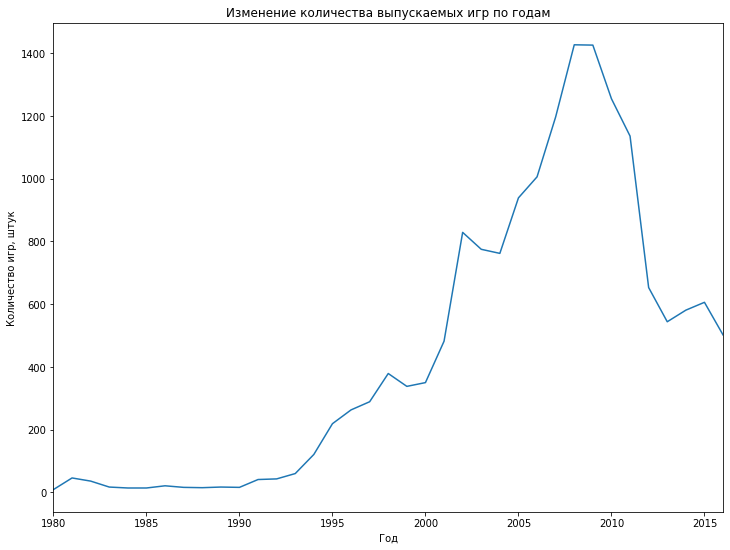

```python
# Строим график зависимости количества выпускаемых игр от года

df.pivot_table('name', 'year_of_release', aggfunc='count').plot(kind='line', figsize=(12, 9), legend=False)

plt.xlabel('Год')
plt.ylabel('Количество игр, штук')
plt.title('Изменение количества выпускаемых игр по годам', fontsize = 12)
plt.show()
```

```python
# Начинаем готовить данные для следующего графика, иллюстрирующего зависимость продаж от платформы.

sales_pivot = (df.pivot_table('total_sales', 'platform', aggfunc='sum')
                .sort_values(by='total_sales', ascending=False))

platforms_list = df['platform'].unique()
years_list = df['year_of_release'].unique()

# Создаем заготовку для таблицы, по данным из которой будем строить график

sales_by_year = pd.DataFrame(years_list)
sales_by_year.columns = ['year_of_release']
sales_by_year = sales_by_year.sort_values('year_of_release').reset_index(drop=True)
```

```python
sales_pivot
```

| platform | total_sales |
| --- | --- |
| PS2 | 1233.56 |
| X360 | 961.24 |
| PS3 | 931.34 |
| Wii | 891.18 |
| DS | 802.78 |
| PS | 727.58 |
| PS4 | 314.14 |
| GBA | 312.88 |
| PSP | 289.53 |
| 3DS | 257.81 |
| PC | 255.76 |
| GB | 254.43 |
| XB | 251.57 |
| NES | 251.05 |
| N64 | 218.01 |
| SNES | 200.04 |
| GC | 196.73 |
| XOne | 159.32 |
| 2600 | 86.48 |
| WiiU | 82.19 |
| PSV | 53.81 |
| SAT | 33.59 |
| GEN | 28.35 |
| DC | 15.95 |
| SCD | 1.86 |
| NG | 1.44 |
| WS | 1.42 |
| TG16 | 0.16 |
| 3DO | 0.10 |
| GG | 0.04 |
| PCFX | 0.03 |

```python
# Заполняем таблицу данными. Это двумерная таблица, строки -- различные платформы, столбцы --
# годы от 1980 до 2016, ячейки заполнены нормализованными (от 0 до 1) в рамках каждой платформы значениями
# продаж (1 -- в соответствующий год наблюдались максимальные суммарные продажи игр для данной
# платформы, 0 -- минимальные).

for platform in platforms_list:
    pmin = df.loc[df['platform'] == platform].groupby('year_of_release')['total_sales'].sum().min()
    pmax = df.loc[df['platform'] == platform].groupby('year_of_release')['total_sales'].sum().max()
    pivplat = df.loc[df['platform'] == platform].pivot_table('total_sales', 'year_of_release', aggfunc='sum')
    pivplat = pivplat.reset_index()
    pivplat.columns = ['year_of_release', platform]
    pivplat[platform] = (pivplat[platform] - pmin) / (pmax - pmin)
    sales_by_year = pivplat.merge(sales_by_year, how='outer')
```

```python
# Приводим таблицу к финальной форме

sales_by_year = sales_by_year.sort_values(by='year_of_release')
sales_by_year = sales_by_year.set_index('year_of_release')
sales_by_year = sales_by_year.T
sales_by_year = sales_by_year.sort_index()
```

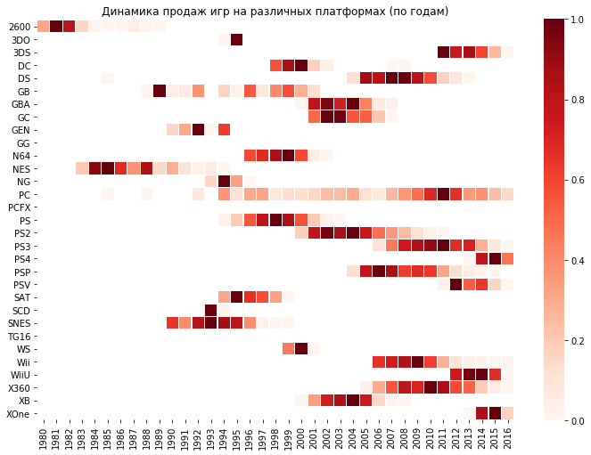

```python
# Вместо того чтобы строить миллион диаграмм распределения значений продаж по годам для разных платформ,
# несколько нетрадиционно используем тепловые карты. По осям -- платформы и года, цвет является индикатором
# уровня продаж по платформе: чем насыщеннее цвет, тем лучше в этот год шли дела у платформы.

f, ax = plt.subplots(figsize=(12, 10))
sns.heatmap(sales_by_year, cmap = 'Reds', square=True, cbar_kws={"shrink": 0.83}, linewidths=.2, ax=ax)
plt.xlabel('')
plt.title('Динамика продаж игр на различных платформах (по годам)', fontsize = 12)
plt.show()
```

```python
# По графику видно, что с 2014 года ситуация на рынке видеоигр серьёзно изменилась. В конце 2013
# вышли приставки нового поколения: PlayStation 4 и Xbox One, что значительно повлияло на продажи игр для других
# платформ. Поэтому за границу актуального периода, по которому дальше будем анализировать
# данные, принимаем 2014 год. В соответсвии с этим критерием формируем датафрейм.

actual_df = df.loc[df['year_of_release'] >= 2014]
```

```python
# Отбираем топ 5 платформ с самыми высокими продажами (по состоянию на 2016 год, потому что
# с 2014 по 2016 распределение долей рынка изменилось).

current_sales = (df.loc[df['year_of_release'] == 2016]
                .pivot_table('total_sales', 'platform', aggfunc='sum')
                .sort_values(by='total_sales', ascending=False))
top5platforms = current_sales.head(5).index.tolist()
top5 = actual_df.query('platform in @top5platforms')
```

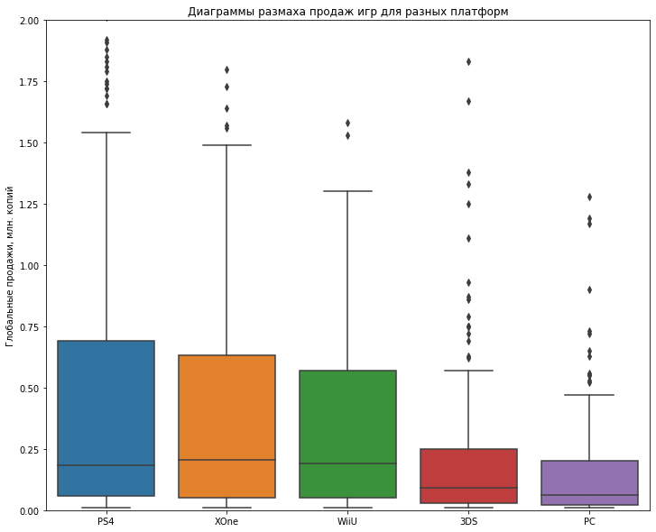

```python
# Строим боксплоты для глобальных продаж по отобранным платформам.

f, ax = plt.subplots(figsize=(12, 10))
sns.boxplot(x='platform', y='total_sales', data=top5,
            orient='v', order=['PS4', 'XOne', 'WiiU', '3DS', 'PC'], ax=ax)
plt.xlabel('')
plt.ylabel('Глобальные продажи, млн. копий')
plt.title('Диаграммы размаха продаж игр для разных платформ', fontsize = 12)
plt.ylim(0, 2)
plt.show()
```

```python
# Те же боксплоты, но в цифрах

top5.groupby('platform')['total_sales'].describe().T
```

| platform | 3DS | PC | PS4 | WiiU | XOne |
| --- | --- | --- | --- | --- | --- |
| count | 212.000000 | 151.000000 | 376.000000 | 73.000000 | 228.000000 |
| mean | 0.408868 | 0.179139 | 0.766356 | 0.588767 | 0.615614 |
| std | 1.188368 | 0.329359 | 1.614969 | 1.161467 | 1.046513 |
| min | 0.010000 | 0.010000 | 0.010000 | 0.010000 | 0.010000 |
| 25% | 0.030000 | 0.020000 | 0.057500 | 0.050000 | 0.050000 |
| 50% | 0.090000 | 0.060000 | 0.185000 | 0.190000 | 0.205000 |
| 75% | 0.250000 | 0.200000 | 0.690000 | 0.570000 | 0.632500 |
| max | 11.680000 | 3.050000 | 14.630000 | 7.090000 | 7.390000 |

```python
# Пишем функцию. Принимает на вход название платформы, строит по ней диаграммы рассеяния с регрессионной прямой
# глобальных продаж для игр на данной платформе в зависимости от оценок пользователей и критиков
# а также считает соответствующие коэффициенты корреляции.

def pl_scatterplot(platform):
    print('')
    print('Связь между продажами и оценками пользователей и критиков для ' + platform)

    pltfsub = (actual_df.loc[actual_df['platform'] == platform]
               .loc[actual_df['total_sales'] < actual_df['total_sales'].quantile(0.995)])

    f, ax = plt.subplots(figsize=(12, 10))
    sns.regplot(x='user_score', y='total_sales', data=pltfsub, scatter=True, ax=ax)
    plt.xlabel('Оценка пользователей')
    plt.ylabel('Глобальные продажи')
    plt.ylim(-0.1, 5)
    plt.show()
    print('')

    cc1 = pltfsub['user_score'].corr(pltfsub['total_sales'])
    print('Коэффициент корреляции Пирсона между оценками пользователей и количеством проданных копий для платформы ' + platform + ' составляет {:.2f}'.format(cc1))
    print('')

    f, ax2 = plt.subplots(figsize=(12, 10))
    sns.regplot(x='critic_score', y='total_sales', data=pltfsub, ax=ax2)
    plt.xlabel('Оценка критиков')
    plt.ylabel('Глобальные продажи')
    plt.ylim(-0.1, 5)
    plt.show()
    print('')

    cc2 = pltfsub['critic_score'].corr(pltfsub['total_sales'])
    print('Коэффициент корреляции Пирсона между оценками критиков и количеством проданных копий для платформы ' + platform + ' составляет {:.2f}'.format(cc2))
    print('-----------------------------------------------------------------------------')
```

```
Связь между продажами и оценками пользователей и критиков для PS4
```

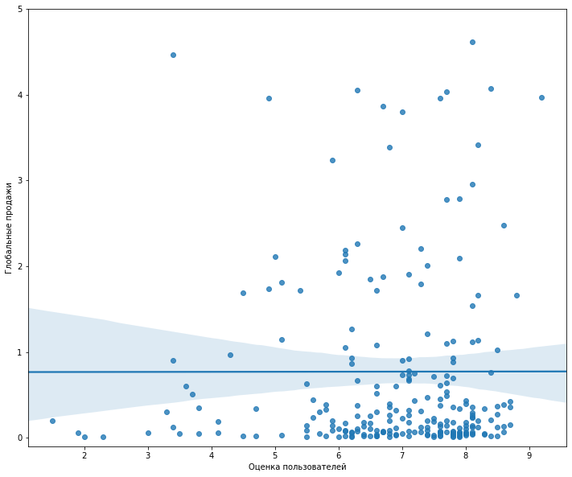

```
Коэффициент корреляции Пирсона между оценками пользователей и количеством проданных копий для платформы PS4 составляет 0.00
```

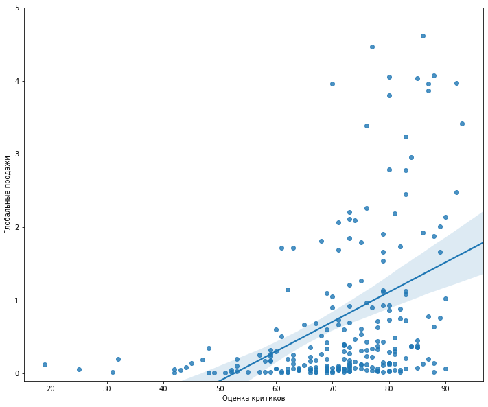

```
Коэффициент корреляции Пирсона между оценками критиков и количеством проданных копий для платформы PS4 составляет 0.40
-----------------------------------------------------------------------------

Связь между продажами и оценками пользователей и критиков для XOne
```

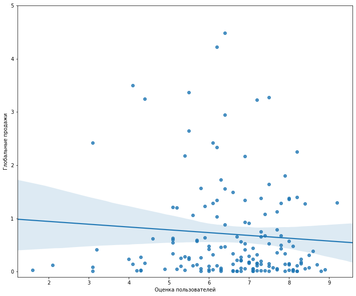

```
Коэффициент корреляции Пирсона между оценками пользователей и количеством проданных копий для платформы XOne составляет -0.07
```

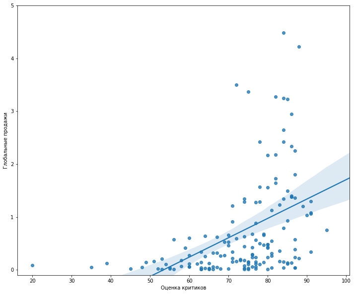

```
Коэффициент корреляции Пирсона между оценками критиков и количеством проданных копий для платформы XOne составляет 0.43
-----------------------------------------------------------------------------

Связь между продажами и оценками пользователей и критиков для 3DS
```

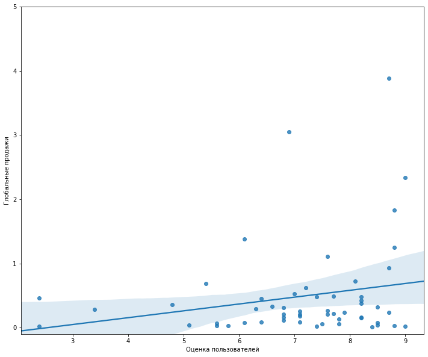

```
Коэффициент корреляции Пирсона между оценками пользователей и количеством проданных копий для платформы 3DS составляет 0.22
```

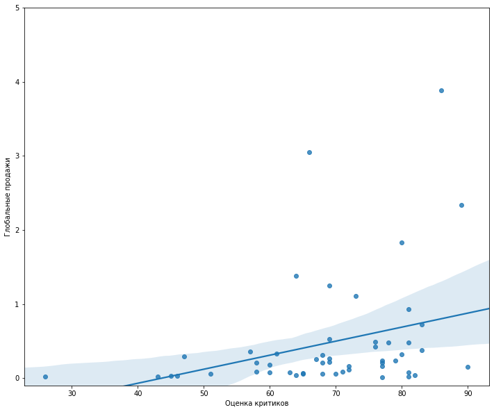

```
Коэффициент корреляции Пирсона между оценками критиков и количеством проданных копий для платформы 3DS составляет 0.31
-----------------------------------------------------------------------------

Связь между продажами и оценками пользователей и критиков для PC
```

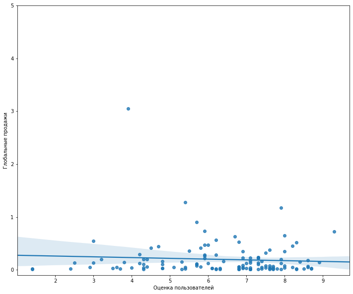

```
Коэффициент корреляции Пирсона между оценками пользователей и количеством проданных копий для платформы PC составляет -0.07
```

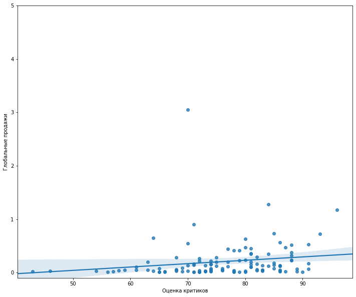

```
Коэффициент корреляции Пирсона между оценками критиков и количеством проданных копий для платформы PC составляет 0.17
-----------------------------------------------------------------------------

Связь между продажами и оценками пользователей и критиков для WiiU
```

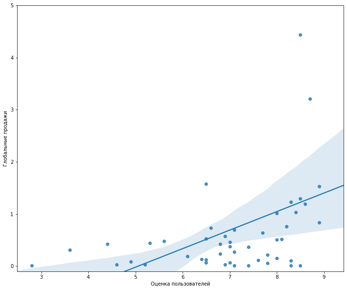

```
Коэффициент корреляции Пирсона между оценками пользователей и количеством проданных копий для платформы WiiU составляет 0.41
```

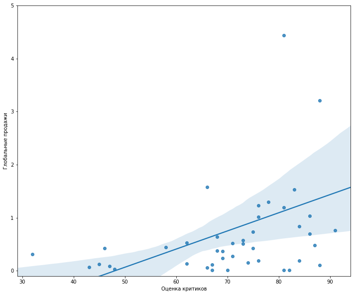

```
Коэффициент корреляции Пирсона между оценками критиков и количеством проданных копий для платформы WiiU составляет 0.37
-----------------------------------------------------------------------------
```

```python
# Применяем функцию для списка из топ5 платформ.

for platform in top5platforms:
    pl_scatterplot(platform)
```